# Homework

Li Mengyao

2025-12-22

# 0915

## Question

Use the R package knitr to produce at least 3 examples. For each example, texts should mix with figures and/or tables. Better to have mathematical formulas.

## Answer

### Example 1

洗好一副编号分别为1,2,…,54 的纸牌，依次抽取出来，若第次抽取到编号的纸牌则称为成功抽取。编写程序估计成功抽取个数的期望和方差，推导理论公式并与模拟结果进行比较。

#### 1.1 理论推导

根据题意，引入
$$X_i=
\begin{cases}
1 & \text{若第i次抽到编号为i的纸牌};\\
0 & \text{若第i次未抽到编号为i的纸牌}.\\
\end{cases}$$
则有$T=\sum\limits_{i=1}^{54}X_i$,易知$E(X_i)=\frac{1}{54}$, $Var(X_i)=\frac{53}{54^2}$,故理论上T的期望$E(T)=E(\sum\limits_{i=1}^{54}X_i)=\sum\limits_{i=1}^{54}E(X_i)=\sum\limits_{i=1}^{54}\frac{1}{54}=1$, T的方差$Var(T)=Var(\sum\limits_{i=1}^{54}X_i)=\sum\limits_{i=1}^{54}Var(X_i)=\sum\limits_{i=1}^{54}\frac{53}{54^2}=\frac{53}{54}=0.9814815$.

#### 1.2 模拟验证

编写R语言程序进行模拟：

```r
set.seed(1111111)
n = 10000 #进行10000次模拟
t <- rep(0,10000)
for(i in 1:n){
  draw <- sample(54) #进行一次抽取
  for (j in 1:54) {
    if(draw[j] == j){
      t[i] = t[i] + 1 #进行一次成功抽取
    }
    else{t[i]=t[i]}
  }
}
mean(t)
```

```
## [1] 0.9944
```

```r
var(t)
```

```
## [1] 0.9842671
```

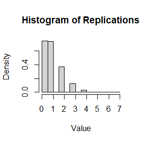

```r
hist(t,
     probability = TRUE,
     main = "Histogram of Replications",
     xlab = "Value")
```

可以发现模拟结果与理论推导结果非常接近。

### Example 2

使用变换法生成Beta(n,1)分布的随机数，其中图像中使用黑线表示经验分布，红线表示理论分布：

```r
# Beta(n,1)分布
set.seed(111)
beta <- function(n,N){
  u <- runif(N,0,1)
  x <- u^(1/n)
  x
}
t <- beta(5,100) # n = 5
knitr::kable(head(t, 10), caption = "随机产生的数据")
```

随机产生的数据

| x |
| --- |
| 0.9007581 |
| 0.9380908 |
| 0.8198594 |
| 0.8756864 |
| 0.8230400 |
| 0.8400504 |
| 0.4032124 |
| 0.8815166 |
| 0.8455300 |
| 0.6227744 |

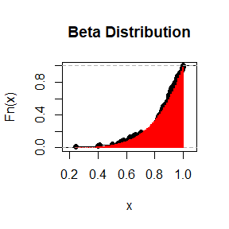

```r
plot.ecdf(t, main="Beta Distribution")
y <- seq(min(t), max(t), 0.01)
lines(y, pbeta(y, shape1 = 5,shape2 = 1),
      col="red", type="h", lwd=2)
```

### Example 3

```r
set.seed(111)
cauchy <- function(N){
  u <- runif(N,0,1)
  x <- tan(pi*(u-0.5))
  x
}
t <- cauchy(100)
knitr::kable(head(t, 10), caption = "随机产生的数据")
```

随机产生的数据

| x |
| --- |
| 0.3007114 |
| 0.8621601 |
| -0.4311655 |
| 0.0469190 |
| -0.4044449 |
| -0.2623317 |
| -29.8550903 |
| 0.1018081 |
| -0.2164102 |
| -3.2991131 |

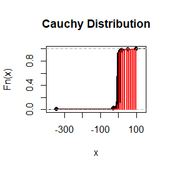

```r
plot.ecdf(t, main="Cauchy Distribution")
y <- seq(min(t), max(t), 10)
lines(y, pcauchy(y), col="red", type="h", lwd=2)
```

# 0922

## 3.4

由密度函数$f(x)=\frac{x}{\sigma^2}e^{-x^2/(2\sigma^2)},\ x\ge 0,\ \sigma>0$，可以得到分布函数$F(x)=1-e^{\frac{-x^2}{2\sigma^2}}$. 令随机变量$U \sim U(0,1)$，则$X\sim \sigma\sqrt{-2log(1-U)}$. 利用逆变换法生成服从Rayleigh($\sigma$)分布的随机变量X:

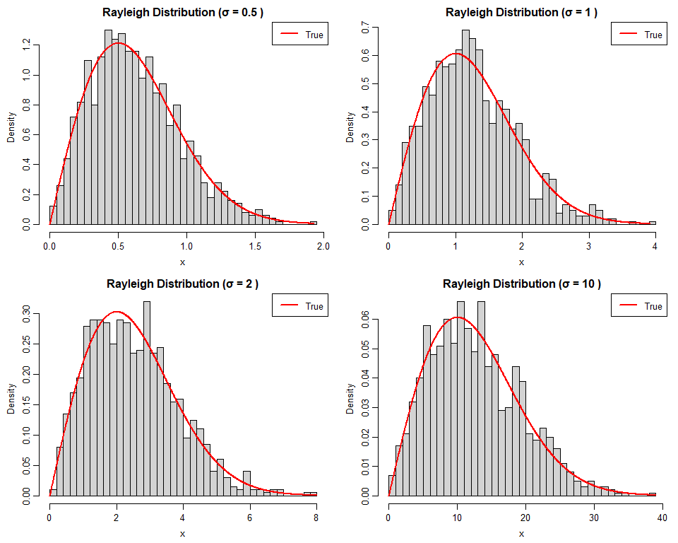

```r
set.seed(123)
n = 1000
generate_rl <- function(sigma) {
  u = runif(n)
  x = sigma*sqrt(-2*log(1-u))
  return(x)
}

par(mfrow = c(2, 2), mar = c(3.5, 3.5, 2, 1), mgp = c(2.1, 0.7, 0))
sigma = c(0.5, 1, 2, 10)   # 考虑不同取值
for (i in sigma) {
  x = generate_rl(i)
  hist(x, breaks = 50, freq = FALSE,
       main = paste("Rayleigh Distribution (σ =", i, ")"),
       xlab = "x", ylab = "Density")
  x_true = seq(0, max(x), length.out = 1000)
  y_true = (x_true/i^2)*exp(-x_true^2/(2*i^2))
  lines(x_true, y_true, col = "red", lwd = 2)
  legend("topright", c("True"), col = c("red"), lwd = 2)
}
```

可以看到，在$\sigma$的四种不同取值下，基于逆变换法的随机数生成模型与对应参数的Rayleigh分布均基本吻合。

## 3.5

首先，我们使用逆变换法生成样本并构建频率表：

```r
set.seed(123)
n = 1000
x = c(0:4)
p = c(0.1, 0.2, 0.2, 0.2, 0.3)
cum_p <- cumsum(p)

# 逆变换法
generate_x <- function(n, x, cum_p){
  u = runif(n)
  samples = numeric(n)
  for (i in 1:n) {
    samples[i] <- x[which(cum_p >= u[i])[1]]
  }
  return(samples)
}

samples_it = generate_x(n, x, cum_p)
ftable = table(samples_it) / n
comparison <- data.frame(
  x = x,
  Theoretical = p,
  Empirical = as.numeric(ftable[as.character(x)])
)
comparison
```

```
##   x Theoretical Empirical
## 1 0         0.1     0.099
## 2 1         0.2     0.197
## 3 2         0.2     0.211
## 4 3         0.2     0.198
## 5 4         0.3     0.295
```

上表是使用逆变换法生成样本的相对频率与真实概率的对比。下面我们直接用R中的sample函数重复这一过程：

```r
set.seed(123)
samples_r = sample(x, n, replace = TRUE, prob = p)
ftable_r = table(samples_r) / n
comparison_r <- data.frame(
  x = x,
  Theoretical = p,
  Empirical = as.numeric(ftable_r[as.character(x)])
)
comparison_r
```

```
##   x Theoretical Empirical
## 1 0         0.1     0.092
## 2 1         0.2     0.203
## 3 2         0.2     0.211
## 4 3         0.2     0.198
## 5 4         0.3     0.296
```

## 3.7

Beta(a,b)分布的密度函数$f(x)=\frac{\Gamma(a+b)}{\Gamma(a)\Gamma(b)}x^{a-1}(1-x)^{b-1},\ 0<x<1$, 令$g(x)=1$, 则可以取$M = \max\ f(x)$, 而当$a>1,\ b>1$时beta(a,b)分布的密度函数最大值在众数$\frac{a-1}{a+b-2}$处取到，对于$a=b=1$，可以采取遍历的方式取最大值：

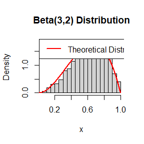

```r
set.seed(123)
n = 1000; i = 0; k = 0
generate_beta <- function(n, a, b){
  if (a>1 && b>1) {
    mode = (a-1)/(a+b-2)
    M = dbeta(mode, a, b)
  }else{
    M = max(dbeta(seq(0.01, 0.99, 0.01), a, b)) + 0.1
  }
  samples = numeric(n)
  while (i < n) {
    x = runif(1)
    k = k + 1
    u = runif(1)
    if (u <= dbeta(x, a, b)/M) {
      i = i + 1
      samples[i] = x
    }
  }
  return(samples)
}

samples = generate_beta(1000, 3, 2)

hist(samples, breaks = 20, freq = FALSE,
     main = "Beta(3,2) Distribution",
     xlab = "x", ylab = "Density")
x_true = seq(0, 1, length.out = 1000)
y_true = dbeta(x_true, 3, 2)
lines(x_true, y_true, col = "red", lwd = 2)
legend("topleft", "Theoretical Distribution", col = "red", lwd = 2)
```

## 3.11

$p_1=0.75$时的混合分布:

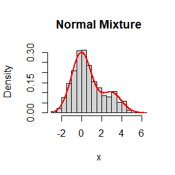

```r
set.seed(123)

draw_hist <- function(p1){
  n = 1000
  X1 = rnorm(n, 0, 1)
  X2 = rnorm(n, 3, 1)
  r = sample(c(0, 1), n, replace = TRUE, prob = c(1-p1, p1))
  Z = r * X1 + (1-r) * X2

  hist(Z, breaks = 20, freq = FALSE,
       main = "Normal Mixture",
       xlab = "x", ylab = "Density")
  x_true = seq(min(Z), max(Z), length.out = 1000)
  y_true = p1 * dnorm(x_true, 0, 1) + (1 - p1) * dnorm(x_true, 3, 1)
  lines(x_true, y_true, col = "red", lwd = 2)
}

draw_hist(0.75)
```

图像呈现并不明显的双峰分布。进一步考虑$p_1=0.5$与$p_1=0.25$：

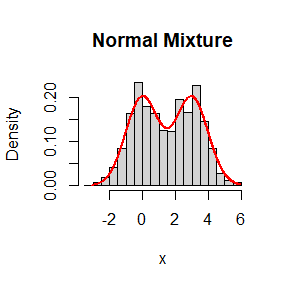

```r
draw_hist(0.5)
```

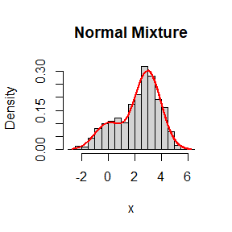

```r
draw_hist(0.25)
```

从图中可以看到当$p_1$趋近于0.5时，混合分布倾向于呈现双峰分布；越趋近0或1，混合分布更倾向于单峰分布。

## 3.12

我们先随机抽取$\Lambda \sim Gamma(r,\beta)$, 再对每一个$\Lambda$抽取$y \sim Exp(\Lambda)$, 并绘制生成数据的直方图：

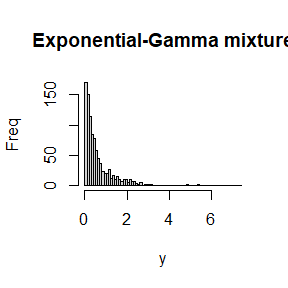

```r
set.seed(123)
n = 1000
r = 4
beta = 2
lambda = rgamma(n, shape = r, rate = beta)
y = rexp(n, lambda)
hist(y, freq = TRUE, breaks = 100,
     main = "Exponential-Gamma mixture",
     xlab = "y", ylab = "Freq")
```

# 0929

### 6.4

编写函数使用Monte Carlo方法估计Beta(3,3)的分布函数：

```r
set.seed(123)
MC_Beta <- function(x, n = 1e5) {
  samples = rbeta(n, 3, 3)
  est = sapply(x, function(xi) mean(samples <= xi))
  return(est)
}

x = seq(0.1, 0.9, by = 0.1)
est_MC = MC_Beta(x)

true = pbeta(x, 3, 3)
```

对比pbeta()生成的结果：

```r
compare = data.frame(
  x = x,
  MC_Estimate = round(est_MC, 4),
  True_pbeta = round(true, 4)
)
compare
```

```
##     x MC_Estimate True_pbeta
## 1 0.1      0.0085     0.0086
## 2 0.2      0.0581     0.0579
## 3 0.3      0.1631     0.1631
## 4 0.4      0.3172     0.3174
## 5 0.5      0.4997     0.5000
## 6 0.6      0.6812     0.6826
## 7 0.7      0.8371     0.8369
## 8 0.8      0.9419     0.9421
## 9 0.9      0.9916     0.9914
```

### 6.6

```r
n = 10000
set.seed(123)
U = runif(n)
Y1 = exp(U)
Y2 = exp(1 - U)
```

普通蒙特卡洛方法估计的方差：

```r
var_simple = var(Y1)
var_simple
```

```
## [1] 0.2378409
```

使用对偶蒙特卡洛计算得到$Cov(e^U,e^{1-U})$:

```r
cov_Y1Y2 = cov(Y1, Y2)
cov_Y1Y2
```

```
## [1] -0.2309274
```

再计算得到$Var(e^U+e^{1-U})$:

```r
var_Y = var(Y1 + Y2)
var_Y
```

```
## [1] 0.01554493
```

计算方差缩减百分比：

```r
var_anti = var((Y1+Y2)/2)
reduction = 1 - var_anti / var_simple
cat("Variance reduction =", reduction, ".\n")
```

```
## Variance reduction = 0.9836604 .
```

### 6.13

考虑截断平移指数分布作为f1，截断标准正态分布函数为f2, 并计算二者的方差比值：

```r
n = 10000
set.seed(123)

# f1
x1 = rexp(n, 1) + 1
w1 = (x1^2/sqrt(2*pi)*exp(-x1^2/2))/exp(-(x1-1))
I1 = mean(w1)
var1 = var(w1)

# f2
rtnorm <- function(n) {
  u = runif(n, pnorm(q=1, mean=1, sd=1), 1)
  qnorm(u, mean=1, sd=1)
}

x2 = rtnorm(n)
dens_f2 = dnorm(x2, 1, 1) / (1 - pnorm(1, 1, 1))
w2 = (x2^2 / sqrt(2*pi) * exp(-x2^2/2)) / dens_f2
I2 = mean(w2)
var2 = var(w2)
var2/var1
```

```
## [1] 0.0768846
```

可以看到截断的标准正态分布函数具有更小的估计方差。

### Monte Carlo

记录蒙特卡洛计算时间，记为$a_n$:

```r
library(rbenchmark)
set.seed(123)
n = c(1e4, 2e4, 4e4, 6e4, 8e4)
an = numeric(5)
for (i in 1:5) {
  ni = n[i]
  x = sample(1:ni, ni,replace = FALSE)
  bm = benchmark(sort(x), replications = 1000, columns = c("test", "replications", "elapsed"))
  an[i] = bm$elapsed
}
an
```

```
## [1] 0.18 0.34 0.53 0.83 1.20
```

建立线性回归模型并画图：

```r
tn = n * log(n)
fit = lm(an ~ tn)
summary(fit)
```

```
##
## Call:
## lm(formula = an ~ tn)
##
## Residuals:
##         1         2         3         4         5
##  0.006215  0.037254 -0.047538 -0.035066  0.039135
##
## Coefficients:
##              Estimate Std. Error t value Pr(>|t|)
## (Intercept) 6.170e-02  3.794e-02   1.626 0.202390
## tn          1.217e-06  6.976e-08  17.445 0.000411 ***
## ---
## Signif. codes:  0 '***' 0.001 '**' 0.01 '*' 0.05 '.' 0.1 ' ' 1
##
## Residual standard error: 0.04636 on 3 degrees of freedom
## Multiple R-squared:  0.9902, Adjusted R-squared:  0.987
## F-statistic: 304.3 on 1 and 3 DF,  p-value: 0.0004105
```

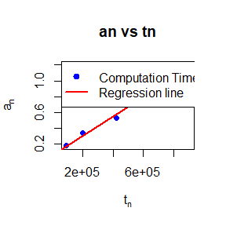

```r
plot(x=tn, y=an, pch = 19, col = "blue",
     xlab = expression(t[n]),
     ylab = expression(a[n]),
     main = "an vs tn")
abline(fit, col = "red", lwd = 2)
legend("topleft", legend = c("Computation Time", "Regression line"),
       col = c("blue", "red"), pch = c(19, NA), lty = c(NA, 1), lwd = 2)
```

可以看到花费时间基本与复杂度$t_n=n\log(n)$成正比。

# 1013

## 6.15

Question: Obtain the stratified importance sampling estimate in Example 6.14 and compare it with the result of Example 6.11.

Answer:

1. 编写数据生成函数，并将结果存储在gen_data.RData文件中：

```r
rm(list = ls())

rf3 <- function(n) { u <- runif(n); -log(1 - u*(1 - exp(-1))) }

gen_data <- function(m, K, seed){
  set.seed(seed)
  m_j = rep(m/K, K)
  a = (0:(K-1))/K
  b = (1:K)/K
  X = vector("list", K)
  for(j in 1:K){
    u = runif(m_j[j])
    p = a[j]
    q = b[j]
    X[[j]] = -log(exp(-p)-u*(exp(-p)-exp(-q)))
  }
  list(X = X, a = a, b = b, m_j = m_j)
}
m = 1e4; K = 5; seed = 123
res = gen_data(m, K, seed)
save(res, file = "E:/code/gen_data.RData")
```

2. 统计推断部分，并在运行前清空内存，加载生成的数据：

```r
rm(list = ls())
load("E:/code/gen_data.RData")

stat_infer <- function(data){
  a = data$a; b = data$b; X = data$X; m_j = data$m_j; K = length(X)
  Pj = (exp(-a) - exp(-b))/(1 - exp(-1))
  r_bar = s2 = numeric(K)
  for(j in 1:K){
    rj = (1 - exp(-1))/(1 + X[[j]]^2)
    r_bar[j] = mean(rj)
    s2[j] = var(rj)
  }
  theta_hat = sum(Pj * r_bar)
  var_hat = sum(Pj^2 * s2 / m_j)
  se_hat = sqrt(var_hat)
  cbind(theta_hat = theta_hat, se_hat = se_hat)
}

inf = as.data.frame(stat_infer(data = res))
write.csv(inf, file = "E:/code/newinf.csv")
```

3. 输出结果：

```r
rm(list = ls())
inf = read.csv("E:/code/newinf.csv")

print_results <- function(inf){
  out <- data.frame(
    method = c("Eg6.14", "Eg6.11"),
    theta_hat = c(inf$theta_hat, 0.5257801),
    mc_se     = c(inf$se_hat, 0.0970314)
  )
  out
}
print_results(inf)
```

```
##   method theta_hat        mc_se
## 1 Eg6.14 0.5249279 0.0001752319
## 2 Eg6.11 0.5257801 0.0970314000
```

可以看到$\hat{\theta}$的估计值相差不大，但是分层抽样时估计的标准差有很大的降低。

## 7.3

Question: Plot the power curves for the t-test in Example 7.9 for sample sizes 10, 20, 30, 40, and 50, but omit the standard error bars. Plot the curves on the same graph, each in a different color or different line type, and include a legend. Comment on the relation between power and sample size.

Answer:

1. 生成并存储模拟数据：

```r
rm(list = ls())

gen_data <- function( n_seq, mu_seq, sigma, m, file){
  set.seed(123)
  dat <- list()
  for(n in n_seq){
    for(mu in mu_seq){
      dat[[paste0("n",n,"_mu",mu)]] <-
        replicate(m, rnorm(n, mu, sigma), simplify = FALSE)
    }
  }
  dat
}

res = gen_data(
  n_seq = c(10,20,30,40,50),
  mu_seq = seq(450,650,10),
  sigma = 100, m = 1000,
  file = "gen_data.rds"
)

save(res, file = "E:/code/gen_data1.RData")
```

2. 计算功效：

```r
rm(list = ls())
load("E:/code/gen_data1.RData")
calc_power <- function(res, mu0, alpha){
  dat <- res
  inf <- data.frame(n = numeric(), mu = numeric(), power = numeric())

  for (nm in names(dat)) {
    parts <- as.numeric(unlist(regmatches(nm, gregexpr("\\d+", nm))))
    n <- parts[1]; mu <- parts[2]
    pvals <- sapply(dat[[nm]], function(x)
      t.test(x, alternative = "greater", mu = mu0)$p.value)
    inf <- rbind(inf, data.frame(n = n, mu = mu, power = mean(pvals <= alpha)))
  }

  inf
}
inf = calc_power(res, 500, 0.05)
write.csv(inf, "E:/code/inf1.csv")
```

3. 结果输出函数:

```r
rm(list = ls())
inf = read.csv("E:/code/inf1.csv")
plot_power <- function(inf){
  cols = 1:length(unique(inf$n))
  plot(NA, xlim = range(inf$mu), ylim = c(0,1),
       xlab = expression(mu), ylab = "Empirical Power",
       main = "Empirical Power Curves")
  abline(v = 500, lty = 2, col = "gray40")

  for(i in seq_along(unique(inf$n))){
    n = unique(inf$n)[i]
    lines(inf$mu[inf$n==n], inf$power[inf$n==n],
          col = cols[i], lwd = 2)
  }
  legend("bottomright", legend = paste0("n=", unique(inf$n)),
         col = cols, lwd = 2, cex = .9)
}
png("E:/code/power_plot.png")
plot_power(inf)
dev.off()
```

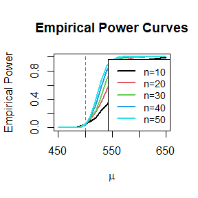

```r
plot_power(inf)
```

## 7.6

Question: Suppose a 95% symmetric t-interval is applied to estimate a mean, but the sample data are non-normal. Then the probability that the confidence interval covers the mean is not necessarily equal to 0.95. Use a Monte Carlo experiment to estimate the coverage probability of the t-interval for random samples of χ2(2) data with sample size n = 20. Compare your t-interval results with the simulation results in Example 7.4. (The t-interval should be more robust to departures from normality than the interval for variance.)

Answer:

1. 使用蒙特卡洛来模拟t区间并计算覆盖率：

```r
rm(list = ls())
gen_data <- function(n, m){
  set.seed(123)
  dat = replicate(m, rchisq(n, df = 2), simplify = FALSE)
  dat
}
dat = gen_data(n=20, m=1000)
save(dat, file = "E:/code/gen_data2.RData")

# ------------------------------------------

rm(list = ls())
load("E:/code/gen_data2.RData")
infer_coverage <- function(dat, mu_true, alpha){
  n = length(dat[[1]])
  cover = sapply(dat, function(x) {
    tcrit = qt(1-alpha/2, df = n-1)
    ci_low = mean(x)-tcrit*sd(x)/sqrt(n)
    ci_up  = mean(x)+tcrit*sd(x)/sqrt(n)
    mu_true >= ci_low & mu_true <= ci_up
  })
  res = data.frame(
    n = n, alpha = alpha,
    coverage = mean(cover),
    se = sqrt(mean(cover)*(1-mean(cover))/length(cover))
  )
  res
}

inf = infer_coverage(dat, 2, 0.05)
write.csv(inf, "E:/code/inf2.csv")

# -------------------------------------------

rm(list = ls())
inf = read.csv("E:/code/inf2.csv")
report_result <- function(inf){
  cat("\n Monte Carlo 估计结果 \n")
  print(inf)
}
report_result(inf)
```

```
##
##  Monte Carlo 估计结果
##   X  n alpha coverage          se
## 1 1 20  0.05    0.908 0.009139803
```

2. 按照Eg7.4中的正态分布区间计算覆盖率：

```r
rm(list = ls())
gen_data <- function(n, m){
  set.seed(123)
  dat = replicate(m, rchisq(n, df = 2), simplify = FALSE)
  dat
}
dat = gen_data(n=20, m=1000)
save(dat, file = "E:/code/gen_data2.RData")

# ------------------------------------------

rm(list = ls())
load("E:/code/gen_data2.RData")
infer_coverage <- function(dat, mu_true, alpha){
  n = length(dat[[1]])
  cover = sapply(dat, function(x) {
    crit = qnorm(1-alpha/2)
    ci_low = mean(x)-crit*sd(x)/sqrt(n)
    ci_up  = mean(x)+crit*sd(x)/sqrt(n)
    mu_true >= ci_low & mu_true <= ci_up
  })
  res = data.frame(
    n = n, alpha = alpha,
    coverage = mean(cover),
    se = sqrt(mean(cover)*(1-mean(cover))/length(cover))
  )
  res
}

inf = infer_coverage(dat, 2, 0.05)
write.csv(inf, "E:/code/inf2.csv")

# -------------------------------------------

rm(list = ls())
inf = read.csv("E:/code/inf2.csv")
report_result <- function(inf){
  cat("\n Monte Carlo 估计结果 \n")
  print(inf)
}
report_result(inf)
```

```
##
##  Monte Carlo 估计结果
##   X  n alpha coverage          se
## 1 1 20  0.05      0.9 0.009486833
```

综合可以看出使用t区间的覆盖率更高，说明其在有偏分布时更稳健。

## 7.A

Question: Use Monte Carlo simulation to investigate whether the empirical Type I error rate of the t-test is approximately equal to the nominal significance level α, when the sampled population is non-normal. The t-test is robust to mild departures from normality. Discuss the simulation results for the cases where the sampled population is (i) χ2(1), (ii) Uniform(0,2), and (iii) Exponential(rate=1). In each case, test H0 : µ = µ0 vs H0 : µ$\neq$ µ0, where µ0 is the mean of χ2(1), Uniform(0,2), and Exponential(1), respectively.

Answer:

1. U(0,2)分布：

```r
rm(list = ls())
gen_data <- function(n, m){
  set.seed(123)
  dat = replicate(m, runif(n, min = 0, max = 2), simplify = FALSE)
  dat
}
dat = gen_data(n=20, m=2000)
save(dat, file = "E:/code/gen_data4.RData")

# ------------------------------------------

rm(list = ls())
load("E:/code/gen_data4.RData")
infer_t1e <- function(dat, mu_true, alpha){
  n = length(dat[[1]])
  pvals = sapply(dat, function(x)
    t.test(x, alternative = "two.sided", mu = mu_true)$p.value)
  type1 = mean(pvals <= alpha)
  res = data.frame(n = n, alpha = alpha, type1 = type1)
}

inf = infer_t1e(dat, 1, 0.05)
write.csv(inf, "E:/code/inf4.csv")

# -------------------------------------------

rm(list = ls())
inf = read.csv("E:/code/inf4.csv")
report_result <- function(inf){
  cat("\n Monte Carlo 估计结果 \n")
  print(inf)
}
report_result(inf)
```

```
##
##  Monte Carlo 估计结果
##   X  n alpha type1
## 1 1 20  0.05 0.053
```

可以看到对于U(0,2)分布，经验一类错误率为0.053，很接近0.05，说明对轻微偏离正态性的分布来说t检验具有稳健性。

2. $\chi^2(1)$分布：

```r
rm(list = ls())
gen_data <- function(n, m){
  set.seed(123)
  dat = replicate(m, rchisq(n, df = 1), simplify = FALSE)
  dat
}
dat = gen_data(n=20, m=2000)
save(dat, file = "E:/code/gen_data3.RData")

# ------------------------------------------

rm(list = ls())
load("E:/code/gen_data3.RData")
infer_t1e <- function(dat, mu_true, alpha){
  n = length(dat[[1]])
  pvals = sapply(dat, function(x)
    t.test(x, alternative = "two.sided", mu = mu_true)$p.value)
  type1 = mean(pvals <= alpha)
  res = data.frame(n = n, alpha = alpha, type1 = type1)
}

inf = infer_t1e(dat, 1, 0.05)
write.csv(inf, "E:/code/inf3.csv")

# -------------------------------------------

rm(list = ls())
inf = read.csv("E:/code/inf3.csv")
report_result <- function(inf){
  cat("\n Monte Carlo 估计结果 \n")
  print(inf)
}
report_result(inf)
```

```
##
##  Monte Carlo 估计结果
##   X  n alpha  type1
## 1 1 20  0.05 0.1005
```

3. Exp(1)分布：

```r
rm(list = ls())
gen_data <- function(n, m){
  set.seed(123)
  dat = replicate(m, rexp(n, rate = 1), simplify = FALSE)
  dat
}
dat = gen_data(n=20, m=2000)
save(dat, file = "E:/code/gen_data5.RData")

# ------------------------------------------

rm(list = ls())
load("E:/code/gen_data5.RData")
infer_t1e <- function(dat, mu_true, alpha){
  n = length(dat[[1]])
  pvals = sapply(dat, function(x)
    t.test(x, alternative = "two.sided", mu = mu_true)$p.value)
  type1 = mean(pvals <= alpha)
  res = data.frame(n = n, alpha = alpha, type1 = type1)
}

inf = infer_t1e(dat, 1, 0.05)
write.csv(inf, "E:/code/inf5.csv")

# -------------------------------------------

rm(list = ls())
inf = read.csv("E:/code/inf5.csv")
report_result <- function(inf){
  cat("\n Monte Carlo 估计结果 \n")
  print(inf)
}
report_result(inf)
```

```
##
##  Monte Carlo 估计结果
##   X  n alpha type1
## 1 1 20  0.05 0.076
```

可以看到Exp(1)分布的经验t1e为0.076，接近0.05；$\chi^2(1)$分布的经验t1e为0.1005，相比0.05有一定偏差。这说明t检验在分布轻微偏离正态性时有较好的稳健性，当分布偏离较多时，其性质也会受到较大影响。

# 1020

## 1

### Question

Of N=1000 hypotheses, 950 are null and 50 are alternative. The p-value under any null hypothesis is uniformly distributed (use the R function runif), and the p-value under any alternative hypothesis follows the beta distribution with parameter 0.1 and 1 (use the R function rbeta). Obtain Bonferroni adjusted p-values and B-H adjusted p-values. Calculate FWER, FDR, and TPR under nominal level α = 0.1 for each of the two adjustment methods based on m = 10,000 simulation replicates. You should output the 6 numbers to a 3×2 table (column names: Bonferroni correction, B-H correction; row names: FWER, FDR, TPR). Comment the results.

### Answer

```r
infer_multi <- function(N = 1000, m0 = 950, alpha = 0.1, m = 10000, seed = 123, out_file = "multi_step1.rds"){
  set.seed(seed)
  fwer_b = fwer_bh = fdr_b = fdr_bh = tpr_b = tpr_bh = 0
  m1 = N - m0
  for(rep in 1:m){
    p = c(runif(m0), rbeta(m1, 0.1, 1))
    padj_b  = p.adjust(p, "bonferroni")
    padj_bh = p.adjust(p, "BH")
    for (padj in list(padj_b, padj_bh)) {
      rej <- padj <= alpha
      R = sum(rej); V = sum(rej[1:m0]); S = sum(rej[(m0+1):N])
      fwer = as.integer(V > 0)
      fdr = if (R > 0) V / R else 0
      tpr = S / m1
      if (identical(padj, padj_b)) { fwer_b = fwer_b + fwer; fdr_b = fdr_b + fdr; tpr_b = tpr_b + tpr }
      else                         { fwer_bh= fwer_bh+ fwer; fdr_bh= fdr_bh+ fdr; tpr_bh= tpr_bh+ tpr }
      }
    }
    res <- matrix(c(fwer_b, fwer_bh,  # FWER
                    fdr_b,  fdr_bh,   # FDR
                    tpr_b,  tpr_bh),  # TPR
                  nrow=3, byrow=TRUE) / m
    dimnames(res) <- list(c("FWER","FDR","TPR"),
                          c("Bonferroni","B-H"))
    saveRDS(list(table=res, params=par), out_file)
    invisible(res)
}

result_multi <- function(in_file = "multi_step1.rds"){
  obj = readRDS(in_file)
  tab = obj$table
  par = obj$params
  print(round(tab, 4))
}

infer_multi()
result_multi()
```

```
##      Bonferroni    B-H
## FWER     0.0873 0.9305
## FDR      0.0045 0.0950
## TPR      0.3967 0.5611
```

可以看到Bonferroni方法的FWER小于显著性水平0.1，而B-H方法相对不保守，有明显更大的FWER。两种方法的FDR都小于显著性水平0.1，Bonferroni方法控制地更好。此外，Bonferroni方法的TPR较低，说明它错过了一些真正的效应，而B-H方法有更高的TPR，能发现更多的真正备择假设。

## 8.4

### Question

Refer to the air-conditioning data set aircondit provided in the boot package. The 12 observations are the times in hours between failures of air-conditioning equipment [68, Example 1.1]: 3, 5,7,18,43,85,91,98,100,130,230,487. Assume that the times between failures follow an exponential model Exp(λ). Obtain the MLE of the hazard rate λ and use bootstrap to estimate the bias and standard error of the estimate.

### Answer

似然函数
$$L(\lambda)=\prod_{i=1}^n
f(x_i)=\prod_{i=1}^n \lambda e^{-\lambda x_i}=\lambda^n
e^{-\lambda\sum_{i=1}^n x_i},$$
对数似然
$$l(\lambda)=n \log (\lambda)-\lambda \sum_{i=1}^n
x_i.$$
从而由
$$\frac{\partial
l}{\partial \lambda}=\frac{n}{\lambda}-\sum_{i=1}^n
x_i,$$
可以得到$\lambda$的MLE估计为
$$\hat{\lambda}=\bar{X}^{-1}.$$

```r
gen_aircond <- function(file = "aircond_step1.rds") {
  x = c(3,5,7,18,43,85,91,98,100,130,230,487)
  saveRDS(x, file); invisible(x)
}

infer_aircond <- function(in_file = "aircond_step1.rds",
                          B, seed,
                          out_file = "aircond_step2.rds") {
  x = readRDS(in_file)
  n = length(x)
  lam_hat = 1 / mean(x)
  set.seed(seed)
  lam_star = replicate(B, {1/mean(sample(x, n, replace = TRUE))})
  bias = mean(lam_star) - lam_hat
  se = sd(lam_star)
  res = list(lam_hat = lam_hat, bias = bias, se = se)
  saveRDS(res, out_file); invisible(res)
}

result_aircond <- function(in_file = "aircond_step2.rds") {
  r = readRDS(in_file)
  cat(sprintf("MLE Estimetor = %.6f\n", r$lam_hat))
  cat(sprintf("Bias (bootstrap) = %.6f\n", r$bias))
  cat(sprintf("SE   (bootstrap) = %.6f\n", r$se))
}

gen_aircond()
infer_aircond(B = 10000, seed = 1)
result_aircond("aircond_step2.rds")
```

```
## MLE Estimetor = 0.009252
## Bias (bootstrap) = 0.001360
## SE   (bootstrap) = 0.004333
```

## 8.7

### Question

Refer to Exercise 8.6. Efron and Tibshirani discuss the following example [91, Chapter 7]. The five-dimensional scores data have a 5×5 covariance matrix Σ, with positive eigenvalues $λ_1 > ··· > λ_5$. In principal components analysis,
$$\theta=\frac{\lambda_1}{\sum_{j=1}^5\lambda_j}$$
measures the proportion of variance explained by the first principal component. Let $\hat{λ}_1 > ··· > \hat{λ}_5$ be the eigenvalues of $\hat{\Sigma}$, where $\hat{\Sigma}$ is the MLE of $\Sigma$. Compute the sample estimate
$$\hat{\theta}=\frac{\hat{\lambda}_1}{\sum_{j=1}^5\hat{\lambda}_j}$$
of $\theta$. Use bootstrap to estimate the bias and standard error of $\hat{\theta}$.

### Answer

```r
library(bootstrap)
gen_scor <- function(file = "scor_step1.rds"){
  X = as.matrix(scor)
  saveRDS(X, file); invisible(X)
}


infer_theta <- function(in_file = "scor_step1.rds",
                        B, seed,
                        out_file = "scor_step2.rds"){
  X = readRDS(in_file)
  n = nrow(X)
  get_theta <- function(M){
    ev = eigen(cov(M), only.values = TRUE)$values
    max(ev) / sum(ev)
  }
  theta_hat = get_theta(X)

  set.seed(seed)
  thetas = replicate(B, {
    idx = sample.int(n, n, replace = TRUE)
    get_theta(X[idx, , drop = FALSE])
  })
  res = list(
    theta_hat = theta_hat,
    bias = mean(thetas) - theta_hat,
    se   = sd(thetas)
  )
  saveRDS(res, out_file); invisible(res)
}

result_theta <- function(in_file = "scor_step2.rds"){
  r = readRDS(in_file)
  cat(sprintf("Theta hat = %.4f\n", r$theta_hat))
  cat(sprintf("Bootstrap bias = %.4f\n", r$bias))
  cat(sprintf("Bootstrap SE = %.4f\n", r$se))
}

gen_scor()
infer_theta(B = 10000, seed = 123)
result_theta("scor_step2.rds")
```

```
## Theta hat = 0.6191
## Bootstrap bias = 0.0018
## Bootstrap SE = 0.0472
```

# 1027

## 8.7

### Question:

Refer to Exercise 8.7. Obtain the jackknife estimates of bias and standard error of $\hat{\theta}$.

### Answer:

```r
library(bootstrap)
gen_scor <- function(file = "scor_step1.rds") {
  X = as.matrix(scor)
  saveRDS(X, file); invisible(X)
}

infer_jackknife <- function(in_file = "scor_step1.rds",
                            out_file = "scor_jack_step2.rds") {
  X = readRDS(in_file)
  n = nrow(X)
  get_theta <- function(M) {
    ev = eigen(cov(M), only.values = TRUE)$values
    max(ev)/sum(ev)
  }
  theta_hat = get_theta(X)         # 原始估计
  theta_jack = numeric(n)          # leave-one-out
  for (i in 1:n){
  theta_jack[i] = get_theta(X[-i, , drop = FALSE])
  }
  theta_bar = mean(theta_jack)
  bias_jack = (n-1)*(theta_bar-theta_hat)
  se_jack = sqrt((n-1)/n*sum((theta_jack-theta_bar)^2))

  res = list(bias_jack = bias_jack, se_jack = se_jack)
  saveRDS(res, out_file); invisible(res)
}

report_jackknife <- function(in_file = "scor_jack_step2.rds") {
  r = readRDS(in_file)
  cat(sprintf("Jackknife 偏差估计 = %.6f\n", r$bias_jack))
  cat(sprintf("Jackknife 标准误 = %.6f\n", r$se_jack))
}

gen_scor()
infer_jackknife()
report_jackknife()
```

```
## Jackknife 偏差估计 = 0.001069
## Jackknife 标准误 = 0.049552
```

## 8.11

### Question:

In Example 8.17, leave-one-out (n-fold) cross validation was used to select the best fitting model. Use leave-two-out cross validation to compare the models.

### Answer:

```r
library(DAAG)
data("ironslag")

magnetic <- ironslag$magnetic
chemical <- ironslag$chemical
n <- length(magnetic)
N2 <- choose(n, 2)
e1 <- e2 <- e3 <- e4 <- numeric(N2)

pairs <- combn(n, 2)
for (k in 1:N2) {
  idx  <- pairs[, k]
  y.tr <- magnetic[-idx]
  x.tr <- chemical[-idx]

  y.te <- magnetic[idx]
  x.te <- chemical[idx]

  ## Model 1: y ~ x
  J1 <- lm(y.tr ~ x.tr)
  yhat1 <- J1$coef[1] + J1$coef[2] * x.te
  e1[k] <- mean((y.te - yhat1)^2)

  ## Model 2: y ~ x + x^2
  J2 <- lm(y.tr ~ x.tr + I(x.tr^2))
  yhat2 <- J2$coef[1] + J2$coef[2] * x.te + J2$coef[3] * x.te^2
  e2[k] <- mean((y.te - yhat2)^2)

  ## Model 3: log(y) ~ x
  J3 <- lm(log(y.tr) ~ x.tr)
  logyhat3 <- J3$coef[1] + J3$coef[2] * x.te
  yhat3 <- exp(logyhat3)
  e3[k] <- mean((y.te - yhat3)^2)

  ## Model 4: log(y) ~ log(x)
  J4 <- lm(log(y.tr) ~ log(x.tr))
  logyhat4 <- J4$coef[1] + J4$coef[2] * log(x.te)
  yhat4 <- exp(logyhat4)
  e4[k] <- mean((y.te - yhat4)^2)
}

c(mean(e1^2), mean(e2^2), mean(e3^2), mean(e4^2))
```

```
## [1]  840.6215  712.6836  825.4295 1048.1579
```

可以看到二次模型的平方误差最小，模型效果最好，与leave-one-out的结果相同。

## 8.A

### Question:

Conduct a Monte Carlo study to estimate the coverage probabilities of the standard normal bootstrap confidence interval, the basic bootstrap confidence interval, and the percentile confidence interval. Sample from a normal population and check the empirical coverage rates for the sample mean. Find the proportion of times that the confidence intervals miss on the left, and the porportion of times that the confidence intervals miss on the right.

### Answer:

```r
set.seed(101)

mc_boot_ci <- function(m = 1e4, n = 50, B = 1000, mu = 0) {
  res <- list(
    normal = c(hit = 0, missL = 0, missR = 0),
    basic  = c(hit = 0, missL = 0, missR = 0),
    perc   = c(hit = 0, missL = 0, missR = 0)
  )

  for (i in 1:m) {
    x = rnorm(n, mean = mu, sd = 1)
    theta_hat = mean(x)
    boot_means = replicate(B, mean(sample(x, n, replace = TRUE)))
    se_boot = sd(boot_means)

    q = quantile(boot_means, c(0.025, 0.975))
    qL = q[1]; qU = q[2]

    ## (1) bootstrap-normal CI
    z = qnorm(0.975)
    ciN_L = theta_hat - z * se_boot
    ciN_U = theta_hat + z * se_boot

    ## (2) basic CI
    ciB_L = 2*theta_hat - qU
    ciB_U = 2*theta_hat - qL

    ## (3) percentile CI
    ciP_L = qL
    ciP_U = qU
    update <- function(ciL, ciU, name) {
      if (mu < ciL) {
        res[[name]]["missL"] <<- res[[name]]["missL"] + 1
      } else if (mu > ciU) {
        res[[name]]["missR"] <<- res[[name]]["missR"] + 1
      } else {
        res[[name]]["hit"]   <<- res[[name]]["hit"]   + 1
      }
    }
    update(ciN_L, ciN_U, "normal")
    update(ciB_L, ciB_U, "basic")
    update(ciP_L, ciP_U, "perc")
  }
  out <- sapply(res, function(v) v / m)
  rownames(out) <- c("coverage", "miss_left", "miss_right")
  return(out)
}

res = mc_boot_ci()
round(res, 4)
```

[output not shown]

## Question

Suppose the population has the exponential distribution with rate $\lambda$.  
The MLE of $\lambda$ is $\hat{\lambda} = \frac{1}{\bar{X}},$ where $\bar{X}$ is the sample mean. It can be derived that $E(\hat{\lambda}) = \lambda \frac{n}{n-1},$ so the estimation bias is $\text{bias}(\hat{\lambda}) = \frac{\lambda}{n-1}.$ The standard error of $\hat{\lambda}$ is $\text{se}(\hat{\lambda}) = \frac{\lambda n}{(n-1)\sqrt{n-2}}.$ Conduct a simulation study to verify the performance of the bootstrap method.

- The true value of $\lambda = 2$.
- The sample size $n = 5, 10, 20$.
- The number of bootstrap replicates $B = 1000$.
- Repeat simulations for $m = 1000$ times.
- Compare the **mean bootstrap bias** and **bootstrap standard error** with the theoretical ones.
- Comment on the results.

### Answer

```r
set.seed(101)

lambda_true = 2
n_vec = c(5, 10, 20)
B = 1000
m = 1000

res <- data.frame(
  n = n_vec,
  boot_bias_mean = NA,
  theory_bias = NA,
  boot_se_mean = NA,
  theory_se = NA
)

for (k in seq_along(n_vec)) {
  n = n_vec[k]
  boot_bias = numeric(m)
  boot_se = numeric(m)

  for (j in 1:m){
    x = rexp(n, lambda_true)
    lambda_hat = 1/mean(x)

    # bootstrap
    boot_lam = replicate(B, {
      xb = sample(x, n, replace = TRUE)
      1 / mean(xb)
    })

    boot_bias[j] = mean(boot_lam) - lambda_hat
    boot_se[j] = sd(boot_lam)
  }

  # Monte Carlo
  res$boot_bias_mean[k] = mean(boot_bias)
  res$boot_se_mean[k] = mean(boot_se)

  # 理论
  res$theory_bias[k] = lambda_true / (n - 1)
  res$theory_se[k] = lambda_true * n / ((n - 1) * sqrt(n - 2))
}

print(res)
```

[output not shown]

# 1103

## 10.3

### Question

Implement the two-sample Cramér-von Mises test for equal distributions as a permutation test using (10.14). Apply the test to the data in Examples 10.1 and 10.2.

### Answer

```r
attach(chickwts)
x = sort(weight[feed == "soybean"])
y = sort(weight[feed == "linseed"])
detach(chickwts)

cvm2 <- function(x, y){
  n = length(x)
  m = length(y)
  N = n + m
  rk = rank(c(x, y), ties.method = "average")
  r = rk[1:n]
  s = rk[(n+1):N]
  U  = n * sum((r - 1:n)^2) + m * sum((s - 1:m)^2)
  U/(n*m*(n+m)) - (4*n*m - 1)/(6*(n+m))
}

options(warn =-1)
W0 = cvm2(x, y)

## 置换检验
R = 999
z = c(x, y)
n = length(x)
m = length(y)
K = 1:(n + m)
W = numeric(R)
for(i in 1:R){
  k  = sample(K, size = n, replace = FALSE)
  x1 = z[k]
  y1 = z[-k]
  W[i] = cvm2(x1, y1)
}
p = mean(c(W0, W) >= W0)
options(warn = 0)
p
```

```
## [1] 1
```

可以看到置换检验的p值约为1，不能拒绝原假设。

## 10.7

### Question

The Count 5 test for equal variances in Section 7.4 is based on the maximum number of extreme points. Example 7.15 shows that the Count 5 criterion is not applicable for unequal sample sizes. Implement a permutation test for equal variance based on the maximum number of extreme points that applies when sample sizes are not necessarily equal. Repeat Example 7.15 using the permutation test.

### Answer

```r
count5test = function(x, y) {
 X = x - mean(x)
 Y = y - mean(y)
 outx = sum(X > max(Y)) + sum(X < min(Y))
 outy = sum(Y > max(X)) + sum(Y < min(X))
 return(max(outx,outy))
}

perm_count5 <- function(x, y, R){
  z = c(x, y)
  n = length(x)
  T0 = count5test(x, y)
  Tstar = numeric(R)
  for (r in 1:R) {
    idx = sample.int(length(z), n)
    x1 = z[idx]
    y1 = z[-idx]
    Tstar[r] = count5test(x1, y1)
  }
  p = (1 + sum(Tstar >= T0)) / (R + 1)
  as.integer(p <= alpha)
}

set.seed(123)
n1 = 20; n2 = 30
m = 10000
alpha = 0.05
alphahat_correct1 = mean(replicate(m, {
  x = rnorm(n1)
  y = rnorm(n2)
  perm_count5(x, y, R = 999)
}))

n3 = 50
m = 10000
alpha = 0.05
alphahat_correct2 = mean(replicate(m, {
  x = rnorm(n1)
  y = rnorm(n3)
  perm_count5(x, y, R = 999)
}))

cat(sprintf("样本量为20/30下的经验 Type I 错误率: %.4f\n", alphahat_correct1))
cat(sprintf("样本量为20/50下的经验 Type I 错误率: %.4f\n", alphahat_correct2))
```

[output not shown]

## Proof

### Question

Prove that the stationary distribution of the M-H sampler with proposal distribution g(r|s) is the target distribution f (x) in the CONTINUOUS case.

### Answer

我们需要证明 $f$ 为平稳分布，即
$$\int f(s)\,K(r,s)\,ds \;=\; f(r).$$

其中，$f(x)$为目标分布，$g(r \mid s)$为建议概率分布，接受概率
$$\alpha(s,r) \;=\; \min\!\left\{\,1,\ \frac{f(r)\,g(s\mid
r)}{f(s)\,g(r\mid s)}\right\}.$$

从而有转移概率核

$$K(r,s)
= \mathbf{I}(s\neq r)\,\alpha(r,s)\,g(s\mid r)
\;+\; \mathbf{I}(s=r)\Big[\,1-\!\int \alpha(r,s)\,g(s\mid r)\,\Big].$$

我们首先需要证明
$$f(s)\,K(r,s) \;=\; f(r)\,K(s,r).$$

对 $s\neq r$，
$$\begin{aligned}
f(s)\,K(r,s)
&= f(s)\,\alpha(r,s)\,g(s\mid r) \\
&= f(s)\,g(s\mid r)\,
\min\!\left\{1,\ \frac{f(r)\,g(s\mid r)}{f(s)\,g(r\mid s)}\right\} \\
&= \min\!\big\{f(s)\,g(s\mid r),\ f(r)\,g(r\mid s)\big\}.
\end{aligned}$$

同理，
$$\begin{aligned}
f(r)\,K(s,r)
&= f(r)\,\alpha(s,r)\,g(r\mid s) \\
&= f(r)\,g(r\mid s)\,
\min\!\left\{1,\ \frac{f(s)\,g(r\mid s)}{f(r)\,g(s\mid r)}\right\} \\
&= \min\!\big\{f(r)\,g(r\mid s),\ f(s)\,g(s\mid r)\big\}.
\end{aligned}$$

因此有$f(s)\,K(r,s)=f(r)\,K(s,r)$ 成立。

接着，两边对 $s$ 积分：
$$\int f(s)\,K(r,s)\,ds
= \int f(r)\,K(s,r)\,ds
= f(r)\int K(s,r)\,ds.$$

因为 $K(\cdot,r)$ 是转移核，$\int K(s,r)\,ds=1$，于是有
$$\int f(s)\,K(r,s)\,ds \;=\; f(r).$$

得证。

# 1110

## 11.6

### Question

Implement a random walk Metropolis sampler for generating the standard Laplace distribution (see Exercise 3.3.2). For the increment, simulate from a normal distribution. Compare the chains generated when different variances are used for the proposal distribution. Also, compute the acceptance rates of each chain.

### Answer

```r
dlap <- function(x) 0.5 * exp(-abs(x))
rw_metropolis_laplace <- function(n, x0 = 25, sigma = 1) {
  x <- numeric(n); x[1] <- x0; acc <- 0L
  for (t in 2:n) {
    y = x[t-1] + rnorm(1, 0, sigma)
    log_alpha = -abs(y) + abs(x[t-1])
    if (log(runif(1)) < log_alpha){
      x[t] = y
      acc = acc + 1L
      }else x[t] <- x[t-1]
  }
  list(chain = x, acc_rate = acc/(n-1), sigma = sigma)
}

set.seed(123)
n_iter = 2000
sigmas = c(0.05, 0.5, 2, 16)

runs <- lapply(sigmas, function(s) rw_metropolis_laplace(n_iter, x0 = 25, sigma = s))
cat("Acceptance rates:\n")
```

```
## Acceptance rates:
```

```r
for (r in runs) cat(sprintf("  sigma = %-4g : %6.2f%%\n", r$sigma, 100*r$acc_rate))
```

```
##   sigma = 0.05 :  97.75%
##   sigma = 0.5  :  84.39%
##   sigma = 2    :  50.43%
##   sigma = 16   :  10.16%
```

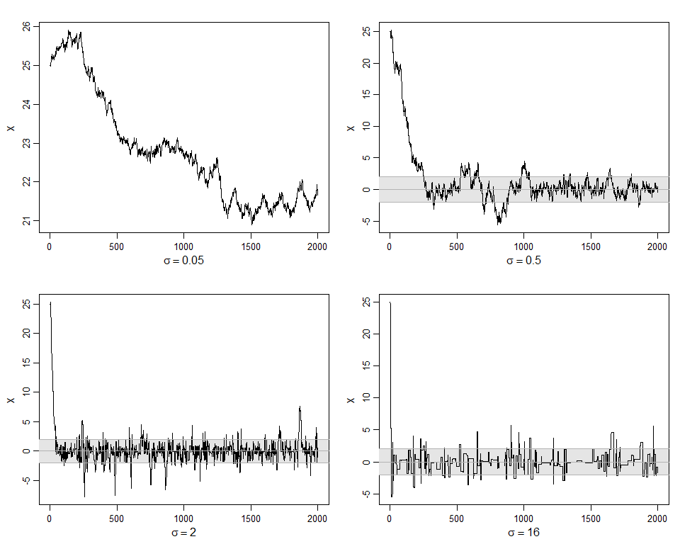

```r
op <- par(mfrow = c(2,2), mar = c(3.5, 3.5, 2, 1), mgp = c(2.1, 0.7, 0))
for (r in runs) {
  xx = r$chain
  yl = range(xx)
  plot(xx, type = "l", xlab = "", ylab = "X", main = "",
       ylim = yl)
  usr = par("usr")
  rect(xleft = usr[1], ybottom = -2, xright = usr[2], ytop = 2,
       col = "gray90", border = NA)
  lines(xx, type = "l")
  abline(h = c(-2, 0, 2), col = "gray70", lwd = 1)
  mtext(bquote(sigma == .(r$sigma)), side = 1, line = 2)
}
```

```r
par(op)
```

## 11.10

### Question

This example appears in [41]. Consider the bivariate density
$$f(x, y) \propto \binom{n}{x} \, y^{x + a - 1}(1 -
y)^{n - x + b - 1},
\quad x = 0, 1, \ldots, n, \; 0 \le y \le 1.$$

It can be shown (see, e.g., [26]) that for fixed a,b,n, the conditional distributions are Binomial(n,y) and Beta(x + a,n − x + b). Use the Gibbs sampler to generate a chain with target joint density f(x,y).

### Answer

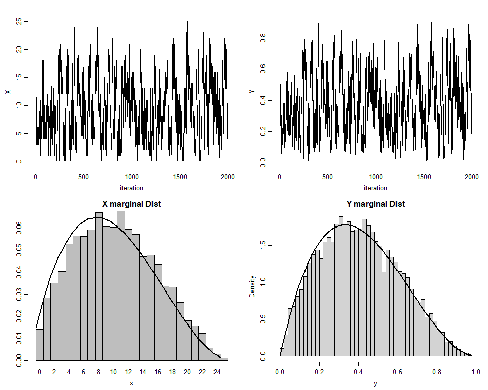

```r
dbetabinom <- function(x, n, a, b) {
  choose(n, x) * beta(x + a, n - x + b) / beta(a, b)
}

true <- function(n = 25, a = 2, b = 3) {
  list(n = n, a = a, b = b,
       Ey = a / (a + b),
       Vy = a*b / ((a + b)^2 * (a + b + 1)))
}

gibbs_xy <- function(truth, n_iter = 10000, burnin = 2000, y0 = 0.5, seed = 123){
  set.seed(seed)
  n = truth$n
  a = truth$a
  b = truth$b
  X = integer(n_iter)
  Y = numeric(n_iter)
  Y[1] = y0
  X[1] = rbinom(1, n, Y[1])
  for (t in 2:n_iter) {
    X[t] = rbinom(1, n, Y[t-1])
    Y[t] = rbeta(1, X[t] + a, n - X[t] + b)
  }
  list(X = X, Y = Y, burnin = burnin, truth = truth, seed = seed)
}

report_xy <- function(sim) {
  n = sim$truth$n
  a = sim$truth$a
  b = sim$truth$b
  X = sim$X
  Y = sim$Y
  keep = (sim$burnin + 1):length(X)
  xk = X[keep]
  yk = Y[keep]


  op <- par(mfrow = c(2, 2), mar = c(3.5, 3.5, 2, 1), mgp = c(2.1, 0.7, 0))
  on.exit(par(op), add = TRUE)

  plot(X[1:2000], type = "l", xlab = "iteration", ylab = "X")
  plot(Y[1:2000], type = "l", xlab = "iteration", ylab = "Y")

  tabx = table(factor(xk, levels = 0:n))
  barplot(tabx / sum(tabx), space = 0, xlab = "x",
          main = "X marginal Dist")
  lines(0:n, dbetabinom(0:n, n, a, b), lwd = 2)

  hist(yk, breaks = 50, freq = FALSE, main = "Y marginal Dist",
       xlab = "y")
  curve(dbeta(x, a, b), add = TRUE, lwd = 2)
  par(op)
}

truth = true(n = 25, a = 2, b = 3)
sim = gibbs_xy(truth, n_iter = 10000, burnin = 2000, y0 = 0.5, seed = 11)
report_xy(sim)
```

## More

### Question

For each of the above exercises, use the Gelman-Rubin method to monitor convergence of the chain, and run the chain until it converges approximately to the target distribution according to $\hat{R} < 1.2$.

### Answer

编写Gelman-Rubin 方法的函数如下：

```r
Gelman.Rubin <- function(psi) {
  psi = as.matrix(psi)
  n = ncol(psi)
  k = nrow(psi)
  psi.means = rowMeans(psi)
  B = n * var(psi.means)
  psi.w = apply(psi, 1, "var")
  W = mean(psi.w)
  v.hat = W * (n - 1) / n + (B / n)
  r.hat = v.hat / W
  return(r.hat)
}

run_gr_for_sigma <- function(sigma = 2, k = 4, n = 15000, b = 1000,
                             x0 = c(-10, -5, 5, 10), seed = 123){
  set.seed(seed)
  X = matrix(0, nrow = k, ncol = n)
  for (i in 1:k) {
    X[i, ] = rw_metropolis_laplace(n, x0 = x0[i], sigma = sigma)$chain
  }
  psi = t(apply(X, 1, cumsum))
  for (i in 1:nrow(psi)){
    psi[i, ] = psi[i, ] / (1:ncol(psi))
  }
  rhat = rep(NA_real_, n)
  for (j in (b+1):n){
    rhat[j] = Gelman.Rubin(psi[, 1:j])
  }
  hit = which(rhat < 1.2)[1]
  plot((b + 1):n, rhat[(b + 1):n], type = "l",
       xlab = "iteration (j)", ylab = expression(hat(R)),
       main = bquote("Gelman–Rubin  " ~ sigma == .(sigma)))
  abline(h = 1.2, lty = 2)
  if (!is.na(hit)) abline(v = hit, col = "gray40", lty = 3)

  invisible(list(X = X, psi = psi, rhat = rhat, hit = hit,
                 sigma = sigma, k = k, n = n, b = b))
}
```

对11.6的结果进行Gelman-Rubin方法诊断，给出$\hat{R}$的收敛轨迹：

```r
sigmas = c(0.1, 0.5, 2, 16)
res_list = lapply(sigmas, function(s) run_gr_for_sigma(sigma = s, k = 4, n = 10000, b = 1000))
```

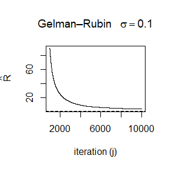

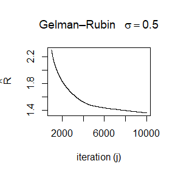

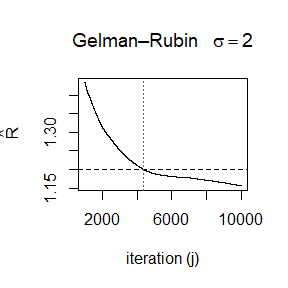

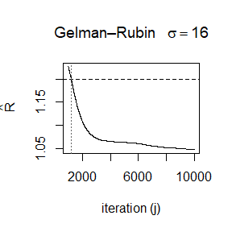

```r
for (i in seq_along(sigmas)) {
  cat(sprintf("sigma = %-5g : first iter with R-hat < 1.2 is %s\n",
              sigmas[i],
              ifelse(is.na(res_list[[i]]$hit), "not reached", res_list[[i]]$hit)))
}
```

```
## sigma = 0.1   : first iter with R-hat < 1.2 is not reached
## sigma = 0.5   : first iter with R-hat < 1.2 is not reached
## sigma = 2     : first iter with R-hat < 1.2 is 4364
## sigma = 16    : first iter with R-hat < 1.2 is 1211
```

```r
gr_for_gibbs <- function(truth,
                         k = 4, n_iter = 15000, burnin = 1000,
                         variable = c("Y","X"),
                         y0_vec = c(0.05, 0.25, 0.75, 0.95),
                         seeds = 1:4,
                         plot_it = TRUE) {
  variable = match.arg(variable)
  stopifnot(length(y0_vec) >= k, length(seeds) >= k)

  Mat = matrix(NA, nrow = k, ncol = n_iter)
  for (i in 1:k) {
    simi = gibbs_xy(truth, n_iter = n_iter, burnin = 0,
                     y0 = y0_vec[i], seed = seeds[i])
    Mat[i, ] <- if (variable == "Y") simi$Y else simi$X
  }

  psi = t(apply(Mat, 1, cumsum))
  for (i in 1:nrow(psi)) psi[i, ] = psi[i, ] / (1:ncol(psi))
  rhat = rep(NA_real_, n_iter)
  for (j in (burnin + 1):n_iter) rhat[j] = Gelman.Rubin(psi[, 1:j])
  hit = which(rhat < 1.2)[1]

  if (plot_it) {
    op = par(mfrow = c(2, 2), mar = c(3.5, 3.5, 2, 1), mgp = c(2.1, 0.7, 0))
    for (i in 1:k) {
      plot(psi[i, (burnin + 1):n_iter], type = "l",
           xlab = "iteration (j)", ylab = expression(psi),
           main = paste(variable, ": Chain", i))
    }
    par(op)

    plot((burnin + 1):n_iter, rhat[(burnin + 1):n_iter], type = "l",
         xlab = "iteration (j)", ylab = expression(hat(R)),
         main = paste0("Gelman–Rubin for ", variable))
    abline(h = 1.2, lty = 2)
    if (!is.na(hit)) abline(v = hit, col = "gray40", lty = 3)
  }

  list(psi = psi, rhat = rhat, hit = hit,
       n_iter = n_iter, burnin = burnin, variable = variable)
}

truth = true(n = 25, a = 2, b = 3)

y0s = seq(0.1, 0.9, length.out = 4)

grY = gr_for_gibbs(truth, k = 4, n_iter = 15000, burnin = 1000,
                   variable = "Y", y0_vec = y0s, seeds = 11:14)

grX = gr_for_gibbs(truth, k = 4, n_iter = 15000, burnin = 1000,
                   variable = "X", y0_vec = y0s, seeds = 21:24)
```

[output not shown]

## 4

### Question(1)

编写函数完成slide P11的功能：

```r
solve_alpha <- function(f0,
                        N = 1e6,
                        b1 = 1, b2 = 1, b3 = -1){
  interval = c(-20, 20)
  set.seed(123)
  x1 = rpois(N, 1)
  x2 = rexp(N, 1)
  x3 = rbinom(N, 1, 0.5)

  g <- function(alpha) {
    eta = alpha + b1 * x1 + b2 * x2 + b3 * x3
    p = 1 / (1 + exp(-eta))
    mean(p) - f0
  }

  solution = uniroot(g, interval = interval)
  alpha = solution$root

  invisible(list(alpha = alpha, solution = solution,
                 f0 = f0, b = c(b1 = b1, b2 = b2, b3 = b3),
                 N = N))
}
```

### Question(2)

调用该函数，输出结果表格：

```r
f0_values = c(0.1, 0.01, 0.001, 0.0001)
alphas = sapply(f0_values, function(f0)
  solve_alpha(f0 = f0, N = 1e6,
              b1 = 1, b2 = 1, b3 = -1)$alpha)
```

```r
out_tab = data.frame(f0 = f0_values, alpha = alphas)
print(out_tab)
```

```
##      f0      alpha
## 1 1e-01  -4.491505
## 2 1e-02  -7.585765
## 3 1e-03 -10.310513
## 4 1e-04 -12.906204
```

### Question(3)

绘制 $-log\,f_0$ vs alpha 散点图：

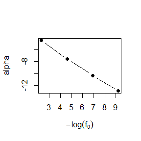

```r
plot(-log(out_tab$f0), out_tab$alpha, type = "b", pch = 19,
     xlab = expression(-log(f[0])), ylab = "alpha")
```

# 1117

## 11.4

### Question

Refer to the Bayesian prediction application in Example 11.3, with the Geometric$(p)$ survival model.  
Prove that the derived parameter $\psi(p) = \frac{p}{1-p}$ does not depend on attained age of the individual in this model.

### Answer

在几何生存模型中，个体生存时间为$k$的概率为

$$\Pr(T = k) = p^{k}(1-p), \quad k = 0,1,2,\ldots,$$

其中$0 < p < 1$。

给定个体已经活到了时间$a$,即$T \ge a$时，记它的未来生存时间为$R_a := T-a. $ 对任意 $k = 0,1,2,\ldots$，有
$$\Pr(R_a = k)
= \Pr(T = a + k \mid T \ge a)
= \frac{\Pr(T = a + k,\, T \ge a)}{\Pr(T \ge a)}
= \frac{\Pr(T = a + k)}{\Pr(T \ge a)}.$$

由$T \sim \text{Geometric}(p)$知，$\Pr(T = a + k) = p^{a+k}(1-p),$ 又有
$$\Pr(T \ge a)
= \sum_{j=a}^{\infty} \Pr(T=j)
= \sum_{j=a}^{\infty} p^{j}(1-p)
= (1-p)\,p^{a} \sum_{j=0}^{\infty} p^{j}
= (1-p)\,p^{a} \cdot \frac{1}{1-p}
= p^{a}.$$
代入得
$$\Pr(R_a = k)
= \frac{p^{a+k}(1-p)}{p^{a}}
= p^{k}(1-p), \quad k = 0,1,2,\ldots$$

这说明对任意给定时间$a$，$R_a$ 的分布与$T$相同，仍然是参数为$p$的几何分布，与$a$ 无关。

又因

$$\psi(p)
= \frac{p}{1-p}
= \sum_{k=0}^{\infty} k\,p^k(1-p)
= \mathbb{E}[T],$$

由于对任意$a$，$R_a$ 仍服从 Geometric$(p)$分布，因此
$$\mathbb{E}[T-a \mid T \ge a]
= \mathbb{E}[R_a]
= \frac{p}{1-p}.$$

它只依赖于参数 $p$，与生存年龄 $a$ 无关。

综上，在 Geometric$(p)$ 生存模型下，$\psi(p) = \frac{p}{1-p}$与个体当前年龄 $a$ 无关。

## 14.1

### Question

Use the simplex algorithm to solve the following problem:

$$\begin{aligned}
\text{Minimize}\quad & 4x + 2y + 9z \\
\text{subject to}\quad
& 2x + y + z \le 2, \\
& x - y + 3z \le 3, \\
& x \ge 0,\; y \ge 0,\; z \ge 0 .
\end{aligned}$$

### Answer

```r
library(boot)

a = c(-4, -2, -9)
A1 = rbind(
  c(2, 1, 1),
  c(1, -1, 3)
)
b1 = c(2, 3)

sol = simplex(a = a, A1 = A1, b1 = b1, maxi = TRUE)
sol
```

```
##
## Linear Programming Results
##
## Call : simplex(a = a, A1 = A1, b1 = b1, maxi = TRUE)
##
## Maximization Problem with Objective Function Coefficients
## x1 x2 x3
## -4 -2 -9
##
##
## Optimal solution has the following values
## x1 x2 x3
##  0  0  0
## The optimal value of the objective  function is 0.
```

## 课后练习

### Question1:

设 $X_1, \dots, X_n \overset{iid}{\sim} Exp(\lambda)$。因为某种原因，只知道 $X_i$ 落在区间 $(U_i, V_i)$内，其中$U_i < V_i$非随机。分别直接极大化似然函数和 EM 算法求解 $\lambda$ 的 MLE，并证明 EM 算法收敛于观测数据的 MLE，且收敛有线性速度。

### Answer1：

指数分布的累积分布函数为 $F(x) = 1 - e^{-\lambda x}$。观测数据为区间 $(U_i, V_i)$，则似然函数为：
$$L(\lambda) = \prod_{i=1}^n P(u_i < X_i < v_i) = \prod_{i=1}^n
\left( e^{-\lambda u_i} - e^{-\lambda v_i} \right)$$

对数似然函数 $l(\lambda)$ 为：
$$l(\lambda) = \sum_{i=1}^n \ln \left( e^{-\lambda u_i} - e^{-\lambda v_i}
\right)$$

为了求 MLE，令导数为 0：
$$\frac{\partial l(\lambda)}{\partial \lambda} = \sum_{i=1}^n
\frac{\frac{\partial}{\partial \lambda}(e^{-\lambda u_i} - e^{-\lambda
v_i})}{e^{-\lambda u_i} - e^{-\lambda v_i}} = \sum_{i=1}^n \frac{-u_i
e^{-\lambda u_i} - (-v_i e^{-\lambda v_i})}{e^{-\lambda u_i} -
e^{-\lambda v_i}} = 0$$

整理得直接 MLE 满足的方程：
$$\sum_{i=1}^n \frac{v_i e^{-\lambda v_i} - u_i e^{-\lambda
u_i}}{e^{-\lambda u_i} - e^{-\lambda v_i}} = 0$$

下面考虑EM算法，有E步 (Expectation Step): 计算完全数据充分统计量的条件期望。对于指数分布，核心是计算 $X$ 在区间 $(u, v)$ 上的条件期望：
$$E[X_i | u_i < X_i < v_i; \lambda^{(t)}] = \frac{\int_{u_i}^{v_i} x
\lambda e^{-\lambda x} dx}{\int_{u_i}^{v_i} \lambda e^{-\lambda x} dx}$$
利用分部积分法可得：
$$\hat{x}_i^{(t)} = \frac{1}{\lambda^{(t)}} + \frac{u_i e^{-\lambda^{(t)}
u_i} - v_i e^{-\lambda^{(t)} v_i}}{e^{-\lambda^{(t)} u_i} -
e^{-\lambda^{(t)} v_i}}$$

M步利用填补后的数据更新参数。指数分布的 MLE 为样本均值的倒数：

$$\lambda^{(t+1)} = \frac{n}{\sum_{i=1}^n \hat{x}_i^{(t)}}$$
即迭代公式为：
$$\frac{n}{\lambda^{(t+1)}} = \sum_{i=1}^n \left( \frac{1}{\lambda^{(t)}}
+ \frac{u_i e^{-\lambda^{(t)} u_i} - v_i e^{-\lambda^{(t)}
v_i}}{e^{-\lambda^{(t)} u_i} - e^{-\lambda^{(t)} v_i}} \right)$$

当 EM 算法收敛时，参数不再变化，即 $\lambda^{(t+1)} = \lambda^{(t)} = \hat{\lambda}$。 将 $\hat{\lambda}$ 代入 M 步的迭代公式中：

$$\frac{n}{\hat{\lambda}} = \sum_{i=1}^n \left( \frac{1}{\hat{\lambda}} +
\frac{u_i e^{-\hat{\lambda} u_i} - v_i e^{-\hat{\lambda}
v_i}}{e^{-\hat{\lambda} u_i} - e^{-\hat{\lambda} v_i}} \right)$$

将右侧求和展开：
$$\frac{n}{\hat{\lambda}} = \sum_{i=1}^n \frac{1}{\hat{\lambda}} +
\sum_{i=1}^n \frac{u_i e^{-\hat{\lambda} u_i} - v_i e^{-\hat{\lambda}
v_i}}{e^{-\hat{\lambda} u_i} - e^{-\hat{\lambda} v_i}}$$

注意到 $\sum_{i=1}^n \frac{1}{\hat{\lambda}} = \frac{n}{\hat{\lambda}}$，因此方程两边消去该项，得到：
$$0 = \sum_{i=1}^n \frac{u_i e^{-\hat{\lambda} u_i} - v_i
e^{-\hat{\lambda} v_i}}{e^{-\hat{\lambda} u_i} - e^{-\hat{\lambda} v_i}}$$

将分子符号反转得到：
$$\sum_{i=1}^n \frac{v_i e^{-\hat{\lambda} v_i} - u_i e^{-\hat{\lambda}
u_i}}{e^{-\hat{\lambda} u_i} - e^{-\hat{\lambda} v_i}} = 0$$

此方程与MLE方法的 Score Equation 完全一致。 因此，EM 算法的收敛点 $\hat{\lambda}$ 满足似然方程，即 EM 算法收敛于观测数据的 MLE。

### Question2：

```r
u <- c(11, 8, 27, 13, 16, 0, 23, 10, 24, 2)
v <- c(12, 9, 28, 14, 17, 1, 24, 11, 25, 3)
n <- length(u)
lambda_init <- 0.1
tol <- 1e-8
max_iter <- 100

log_lik_func <- function(lambda, u, v) {
  sum(log(exp(-lambda * u) - exp(-lambda * v)))
}

newton_raphson <- function(u, v, lambda_start, tol, max_iter) {
  lambda <- lambda_start
  path <- c(lambda)
  for (i in 1:max_iter) {
    delta <- v - u
    term1 <- -u
    term2 <- delta / (exp(lambda * delta) - 1)
    score <- sum(term1 + term2)
    hessian <- -sum((delta^2 * exp(lambda * delta)) / (exp(lambda * delta) - 1)^2)
    lambda_new <- lambda - score / hessian
    path <- c(path, lambda_new)
    if (abs(lambda_new - lambda) < tol) {
      return(list(est = lambda_new, iter = i, path = path, converged = TRUE))
    }
    lambda <- lambda_new
  }
  return(list(est = lambda, iter = max_iter, path = path, converged = FALSE))
}

em_algorithm <- function(u, v, lambda_start, tol, max_iter) {
  lambda <- lambda_start
  path <- c(lambda)
  n <- length(u)
  for (i in 1:max_iter) {
    denom <- exp(-lambda * u) - exp(-lambda * v)
    num_part <- u * exp(-lambda * u) - v * exp(-lambda * v)
    expected_X <- (1 / lambda) + (num_part / denom)
    lambda_new <- n / sum(expected_X)
    path <- c(path, lambda_new)
    if (abs(lambda_new - lambda) < tol) {
      return(list(est = lambda_new, iter = i, path = path, converged = TRUE))
    }
    lambda <- lambda_new
  }
  return(list(est = lambda, iter = max_iter, path = path, converged = FALSE))
}

res_nr <- newton_raphson(u, v, lambda_init, tol, max_iter)
res_em <- em_algorithm(u, v, lambda_init, tol, max_iter)

cat(sprintf("Newton-Raphson (MLE): 估计值 = %.4f, 迭代次数 = %d\n", res_nr$est, res_nr$iter))
```

```
## Newton-Raphson (MLE): 估计值 = 0.0720, 迭代次数 = 6
```

```r
cat(sprintf("EM Algorithm (EM):    估计值 = %.4f, 迭代次数 = %d\n", res_em$est, res_em$iter))
```

```
## EM Algorithm (EM):    估计值 = 0.0720, 迭代次数 = 3
```

```r
diff_est <- abs(res_nr$est - res_em$est)
cat(sprintf("两者结果差异: %.4f \n", diff_est))
```

```
## 两者结果差异: 0.0000
```

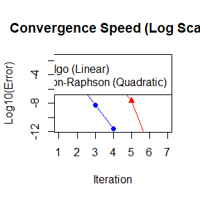

```r
true_mle <- res_nr$est
nr_error <- abs(res_nr$path - true_mle) + 1e-20
em_error <- abs(res_em$path - true_mle) + 1e-20

max_len <- max(length(nr_error), length(em_error))
nr_plot <- c(nr_error, rep(NA, max_len - length(nr_error)))
em_plot <- c(em_error, rep(NA, max_len - length(em_error)))

plot(1:max_len, log10(em_plot), type = "o", col = "blue", pch = 16,
     xlab = "Iteration", ylab = "Log10(Error)",
     main = "Convergence Speed (Log Scale)")
lines(1:max_len, log10(nr_plot), type = "o", col = "red", pch = 17)
legend("topright", legend = c("EM Algo (Linear)", "Newton-Raphson (Quadratic)"),
       col = c("blue", "red"), pch = c(16, 17), lty = 1)
```

# 1124

## 6

### Question

Implement a combination of Map() and vapply() to create an lapply() variant that iterates in parallel over all of its inputs and stores its outputs in a vector (or a matrix). What arguments should the function take?

### Answer

需要的参数有进行迭代的输入，函数与输出形式：

```r
vmap <- function(FUN, ..., FUN.VALUE) {
  args = list(...)
  n = length(args[[1]])

  vapply(
    X = seq_len(n),
    FUN = function(i) {
      ith_args = Map(`[`, args, i)
      do.call(FUN, ith_args)
    },
    FUN.VALUE = FUN.VALUE
  )
}
```

以两个向量相加为例：

```r
x = 1:5
y = 6:10

vmap(`+`, x, y, FUN.VALUE = numeric(1))
```

```
## [1]  7  9 11 13 15
```

可以看到是将所有输入重复进行相加操作。

## 4

### Question

Make a faster version of chisq.test() that only computes the chi-square test statistic when the input is two numeric vectors with no missing values. You can try simplifying chisq.test() or by coding from the mathematical definition (http://en.wikipedia.org/wiki/Pearson%27s_chi-squared_test).

### Answer

```r
fast_chisq <- function(x, y) {
  stopifnot(is.numeric(x), is.numeric(y))
  stopifnot(length(x) == length(y))

  tab = table(x, y)
  rs = rowSums(tab)
  cs = colSums(tab)
  n = sum(tab)
  E = outer(rs, cs, "*") / n
  X2 = sum((tab - E)^2 / E)
  return(X2)
}
```

## 5

### Question

Can you make a faster version of table() for the case of an input of two integer vectors with no missing values? Can you use it to speed up your chi-square test?

更快的table()函数：

```r
fast_table <- function(x, y) {
  ix = x - min(x) + 1
  iy = y - min(y) + 1
  nx = max(ix)
  ny = max(iy)
  tab = matrix(0L, nrow = nx, ncol = ny)
  for (i in seq_along(ix)) {
    tab[ix[i], iy[i]] <- tab[ix[i], iy[i]] + 1L
  }
  return(tab)
}
```

将fast_table()函数用于fast_chisq()函数：

```r
faster_chisq <- function(x, y) {
  tab = fast_table(x, y)
  rs = rowSums(tab)
  cs = colSums(tab)
  n = sum(tab)
  E = outer(rs, cs, "*") / n
  X2 = sum((tab - E)^2 / E)
  return(X2)
}
```

# 1201

## Question1

Write an Rcpp function for Exercise 11.8 (page 334, Statistical Computing with R, 2nd edition).

Rao [232, Sec. 5g] presented an example on genetic linkage of 197 animals in four categories (also discussed in [70, 110, 179, 280]). The group sizes are (125,18,20,34). Assume that the probabilities of the corresponding multinomial distribution are
$$(\frac{1}{2}+\frac{\theta}{4},\,\frac{1-\theta}{4},\,\frac{1-\theta}{4},\,
\frac{\theta}{4}).$$
Estimate the posterior distribution of θ given the observed sample, using one of the methods in this chapter.

## Answer

```r
n_obs = c(125, 18, 20, 34)

logpost_theta <- function(theta, n = n_obs) {
  if (theta <= 0 || theta >= 1) return(-Inf)
  p1 = 0.5 + theta / 4
  p2 = (1 - theta) / 4
  p3 = (1 - theta) / 4
  p4 = theta / 4
  l = sum(n * log(c(p1, p2, p3, p4)))
  if (any(c(p1, p2, p3, p4) <= 0)) return(-Inf)
  return(l)
}

rw_theta_R <- function(N, theta0, w, n = n_obs) {
  theta = numeric(N)
  theta[1] = theta0
  accept = 0L
  for (i in 2:N) {
    y = theta[i - 1] + runif(1, -w, w)
    if (y <= 0 || y >= 1) {
      theta[i] = theta[i - 1]
      next
    }
    logalpha = logpost_theta(y, n) - logpost_theta(theta[i - 1], n)
    if (log(runif(1)) < logalpha) {
      theta[i] = y
      accept = accept + 1L
    } else {
      theta[i] = theta[i - 1]
    }
  }
  list(theta = theta, acc_rate = accept / (N - 1))
}
```

再编写cpp版本：

```cpp
#include <Rcpp.h>
using namespace Rcpp;

double logpost_theta_cpp(double theta, const NumericVector &n) {
  if (theta <= 0.0 || theta >= 1.0) return R_NegInf;

  double p1 = 0.5 + theta / 4.0;
  double p2 = (1.0 - theta) / 4.0;
  double p3 = p2;
  double p4 = theta / 4.0;

  if (p1 <= 0.0 || p2 <= 0.0 || p3 <= 0.0 || p4 <= 0.0)
    return R_NegInf;

  double loglik = n[0] * std::log(p1)
    + n[1] * std::log(p2)
    + n[2] * std::log(p3)
    + n[3] * std::log(p4);
    return loglik;
}

// [[Rcpp::export]]
List rw_theta_cpp(int N, double theta0, double w, NumericVector n) {
  NumericVector theta(N);
  theta[0] = theta0;
  int accept = 0;

  for (int i = 1; i < N; ++i) {
    double y = theta[i - 1] + R::runif(-w, w);

    if (y <= 0.0 || y >= 1.0) {
      theta[i] = theta[i - 1];
      continue;
    }

    double logalpha = logpost_theta_cpp(y, n) - logpost_theta_cpp(theta[i - 1], n);
    double u = std::log(R::runif(0.0, 1.0));

    if (u < logalpha) {
      theta[i] = y;
      ++accept;
    } else {
      theta[i] = theta[i - 1];
    }
  }

  return List::create(
    Named("theta") = theta,
    Named("acc_rate") = static_cast<double>(accept) / (N - 1)
  );
}
```

```r
library(Rcpp)
Rcpp::sourceCpp("E:/code/rw_theta.cpp")
```

## Question2

Compare the corresponding generated random numbers with those by the R function you wrote before using the function “qqplot”.

## Answer

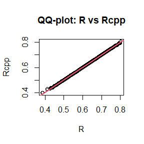

```r
set.seed(123)
N = 100000
w = 0.2
n = n_obs
th0 = 0.3

## R
out_R = rw_theta_R(N, th0, w, n)
theta_R = out_R$theta

## Rcpp
out_cpp = rw_theta_cpp(N, th0, w, n)
theta_cpp = out_cpp$theta

burn = 1000
theta_Rb = theta_R[-(1:burn)]
theta_cppb = theta_cpp[-(1:burn)]

qqplot(theta_Rb, theta_cppb,
       xlab = "R",
       ylab = "Rcpp",
       main = "QQ-plot: R vs Rcpp")
abline(0, 1, col = 2, lwd = 2)
```

## Question3

Compare the computation time of the two functions with the function “microbenchmark”.

## Answer

```r
library(microbenchmark)
set.seed(123)
N = 100000
bench <- microbenchmark(
  R = rw_theta_R(N, th0, w, n),
  Rcpp = rw_theta_cpp(N, th0, w, n),
  times = 20L
)
print(bench)
```

```
## Unit: milliseconds
##  expr      min        lq      mean    median       uq      max neval cld
##     R 632.7934 641.35595 657.77876 647.11555 664.6796 732.8451    20  a
##  Rcpp  26.3249  26.64095  27.66913  27.00575  28.8580  30.3527    20   b
```

使用 qqplot 比较 R 与 Rcpp 生成的样本，可以发现生成的样本点基本落在 y=x 附近，说明两种编码方式实现的方法得到的后验分布是相同的。而 使用 microbenchmark 比较运行时间，可以发现 Rcpp 版本远远快于 R 版本，说明使用C++能大幅提升算法计算速度。